# Market Basket Analysis Notebook by SH

Install required Packages

```r
#install.packages("RCurl")
#install.packages("xlsx")
#install.packages("plyr")
```

Import Packages

```r
# Load the libraries
library(Matrix)
library(arules)
library(arulesViz)
library(datasets)
library(httr)
library(jsonlite)
library(RCurl)
#library(xlsx) # has dependency on the 'rJava' package requiring Java to be installed
library(readxl)
library(tidyverse)
library(knitr)
library(ggplot2)
library(lubridate)
library(tidyr)
library(dplyr)
library(plyr)
```

Load Data from UCI repository

```r
############################################################
# Read in the dataset
retail <- read_excel("C:/Users/ac27802/Desktop/Market_Basket_Analysis_OnlineRetail/data/Online Retail.xlsx")
head(retail)
```

| InvoiceNo | StockCode | Description | Quantity | InvoiceDate | UnitPrice | CustomerID | Country |
| --- | --- | --- | --- | --- | --- | --- | --- |
| 536365 | 85123A | WHITE HANGING HEART T-LIGHT HOLDER | 6 | 2010-12-01 08:26:00 | 2.5 | 17850 | United Kingdom |
| 536365 | 71053 | WHITE METAL LANTERN | 6 | 2010-12-01 08:26:00 | 3.4 | 17850 | United Kingdom |
| 536365 | 84406B | CREAM CUPID HEARTS COAT HANGER | 8 | 2010-12-01 08:26:00 | 2.8 | 17850 | United Kingdom |
| 536365 | 84029G | KNITTED UNION FLAG HOT WATER BOTTLE | 6 | 2010-12-01 08:26:00 | 3.4 | 17850 | United Kingdom |
| 536365 | 84029E | RED WOOLLY HOTTIE WHITE HEART. | 6 | 2010-12-01 08:26:00 | 3.4 | 17850 | United Kingdom |
| 536365 | 22752 | SET 7 BABUSHKA NESTING BOXES | 2 | 2010-12-01 08:26:00 | 7.6 | 17850 | United Kingdom |

```r
summary(retail)
```

```
  InvoiceNo          StockCode         Description           Quantity
 Length:541909      Length:541909      Length:541909      Min.   :-80995
 Class :character   Class :character   Class :character   1st Qu.:     1
 Mode  :character   Mode  :character   Mode  :character   Median :     3
                                                          Mean   :    10
                                                          3rd Qu.:    10
                                                          Max.   : 80995

  InvoiceDate                       UnitPrice        CustomerID       Country
 Min.   :2010-12-01 08:26:00.00   Min.   :-11062   Min.   :12346    Length:541909
 1st Qu.:2011-03-28 11:34:00.00   1st Qu.:     1   1st Qu.:13953    Class :character
 Median :2011-07-19 17:17:00.00   Median :     2   Median :15152    Mode  :character
 Mean   :2011-07-04 13:34:57.16   Mean   :     5   Mean   :15288
 3rd Qu.:2011-10-19 11:27:00.00   3rd Qu.:     4   3rd Qu.:16791
 Max.   :2011-12-09 12:50:00.00   Max.   : 38970   Max.   :18287
                                                   NA's   :135080
```

```r
glimpse(retail)
```

```
Rows: 541,909
Columns: 8
$ InvoiceNo   <chr> "536365", "536365", "536365", "536365", "536365", "536365", "536365", "536366"…
$ StockCode   <chr> "85123A", "71053", "84406B", "84029G", "84029E", "22752", "21730", "22633", "2…
$ Description <chr> "WHITE HANGING HEART T-LIGHT HOLDER", "WHITE METAL LANTERN", "CREAM CUPID HEAR…
$ Quantity    <dbl> 6, 6, 8, 6, 6, 2, 6, 6, 6, 32, 6, 6, 8, 6, 6, 3, 2, 3, 3, 4, 4, 6, 3, 3, 3, 3,…
$ InvoiceDate <dttm> 2010-12-01 08:26:00, 2010-12-01 08:26:00, 2010-12-01 08:26:00, 2010-12-01 08:…
$ UnitPrice   <dbl> 2.55, 3.39, 2.75, 3.39, 3.39, 7.65, 4.25, 1.85, 1.85, 1.69, 2.10, 2.10, 3.75, …
$ CustomerID  <dbl> 17850, 17850, 17850, 17850, 17850, 17850, 17850, 17850, 17850, 13047, 13047, 1…
$ Country     <chr> "United Kingdom", "United Kingdom", "United Kingdom", "United Kingdom", "Unite…
```

```r
###########################################################
```

```r
#Convert and edit Quantity into numeric
Quantity <- as.numeric(retail$Quantity)
glimpse(retail)
```

```
Rows: 541,909
Columns: 8
$ InvoiceNo   <chr> "536365", "536365", "536365", "536365", "536365", "536365", "536365", "536366"…
$ StockCode   <chr> "85123A", "71053", "84406B", "84029G", "84029E", "22752", "21730", "22633", "2…
$ Description <chr> "WHITE HANGING HEART T-LIGHT HOLDER", "WHITE METAL LANTERN", "CREAM CUPID HEAR…
$ Quantity    <dbl> 6, 6, 8, 6, 6, 2, 6, 6, 6, 32, 6, 6, 8, 6, 6, 3, 2, 3, 3, 4, 4, 6, 3, 3, 3, 3,…
$ InvoiceDate <dttm> 2010-12-01 08:26:00, 2010-12-01 08:26:00, 2010-12-01 08:26:00, 2010-12-01 08:…
$ UnitPrice   <dbl> 2.55, 3.39, 2.75, 3.39, 3.39, 7.65, 4.25, 1.85, 1.85, 1.69, 2.10, 2.10, 3.75, …
$ CustomerID  <dbl> 17850, 17850, 17850, 17850, 17850, 17850, 17850, 17850, 17850, 13047, 13047, 1…
$ Country     <chr> "United Kingdom", "United Kingdom", "United Kingdom", "United Kingdom", "Unite…
```

```r
# Check dataframe shape

nrow(retail)
```

```
[1] 541909
```

```r
ncol(retail)
```

```
[1] 8
```

```r
# Check to see missing values

sum(is.na(retail)) #total number of missing values is 136534
```

```
[1] 136534
```

```r
colSums(is.na(retail)) #further check to see where these missing values fall under what columns
```

```
  InvoiceNo   StockCode Description    Quantity InvoiceDate   UnitPrice  CustomerID     Country
          0           0        1454           0           0           0      135080           0
```

```r
# Return dataframe using complete.cases which returns a logical vector with cases that are complete, i.e., no missing value.
#sum(complete.cases(retail))
retail <- retail[complete.cases(retail), ] # remove missing values


# Use gsub() to remove quotes from the description column to avoid error -EOF within quoted stringWarning: EOF within quoted stringWarning:
retail$Description <- gsub('"', '', retail$Description)
```

```r
# Recheck dataframe shape after removing missing values

nrow(retail)
```

```
[1] 406829
```

```r
ncol(retail)
```

```
[1] 8
```

Transform data into a transaction data format in order for arules to read (one row per transaction)

```r
# select only description and invoiceNo columns

retail_selected <- retail %>%
  select(InvoiceNo, Description)
retail_selected
```

| InvoiceNo | Description |
| --- | --- |
| 536365 | WHITE HANGING HEART T-LIGHT HOLDER |
| 536365 | WHITE METAL LANTERN |
| 536365 | CREAM CUPID HEARTS COAT HANGER |
| 536365 | KNITTED UNION FLAG HOT WATER BOTTLE |
| 536365 | RED WOOLLY HOTTIE WHITE HEART. |
| 536365 | SET 7 BABUSHKA NESTING BOXES |
| 536365 | GLASS STAR FROSTED T-LIGHT HOLDER |
| 536366 | HAND WARMER UNION JACK |
| 536366 | HAND WARMER RED POLKA DOT |
| 536367 | ASSORTED COLOUR BIRD ORNAMENT |

[output cut: 990 more lines]

```r
# count number of unique rows in a column
n_distinct(retail_selected$InvoiceNo) # we are seeing 22190 unique invoices/transactions
```

```
[1] 22190
```

```r
# Collapse description column into one row per transaction
#ddply(dataframe, variables_to_be_used_to_split_data_frame, function_to_be_applied)
retail_new <- ddply(retail_selected
                     , .(InvoiceNo) #columns you want to split the data frame by
                     , summarize
                     , Description_collapsed = paste(Description, collapse=",")
)

retail_new
```

| InvoiceNo | Description_collapsed |
| --- | --- |
| 536365 | WHITE HANGING HEART T-LIGHT HOLDER,WHITE METAL LANTERN,CREAM CUPID HEARTS COAT HANGER,KNITTED UNION FLAG HOT WATER BOTTLE,RED WOOLLY HOTTIE WHITE HEART.,SET 7 BABUSHKA NESTING BOXES,GLASS STAR FROSTED… |
| 536366 | HAND WARMER UNION JACK,HAND WARMER RED POLKA DOT |
| 536367 | ASSORTED COLOUR BIRD ORNAMENT,POPPY'S PLAYHOUSE BEDROOM,POPPY'S PLAYHOUSE KITCHEN,FELTCRAFT PRINCESS CHARLOTTE DOLL,IVORY KNITTED MUG COSY,BOX OF 6 ASSORTED COLOUR TEASPOONS,BOX OF VINTAGE JIGSAW BLOC… |
| 536368 | JAM MAKING SET WITH JARS,RED COAT RACK PARIS FASHION,YELLOW COAT RACK PARIS FASHION,BLUE COAT RACK PARIS FASHION |
| 536369 | BATH BUILDING BLOCK WORD |
| 536370 | ALARM CLOCK BAKELIKE PINK,ALARM CLOCK BAKELIKE RED,ALARM CLOCK BAKELIKE GREEN,PANDA AND BUNNIES STICKER SHEET,STARS GIFT TAPE,INFLATABLE POLITICAL GLOBE,VINTAGE HEADS AND TAILS CARD GAME,SET/2 RED RET… |
| 536371 | PAPER CHAIN KIT 50'S CHRISTMAS |
| 536372 | HAND WARMER RED POLKA DOT,HAND WARMER UNION JACK |
| 536373 | WHITE HANGING HEART T-LIGHT HOLDER,WHITE METAL LANTERN,CREAM CUPID HEARTS COAT HANGER,EDWARDIAN PARASOL RED,RETRO COFFEE MUGS ASSORTED,SAVE THE PLANET MUG,VINTAGE BILLBOARD DRINK ME MUG,VINTAGE BILLBO… |
| 536374 | VICTORIAN SEWING BOX LARGE |

[output cut: 990 more lines]

```r
head(retail_new, 3)
```

|  | InvoiceNo | Description_collapsed |
| --- | --- | --- |
| 1 | 536365 | WHITE HANGING HEART T-LIGHT HOLDER,WHITE METAL LANTERN,CREAM CUPID HEARTS COAT HANGER,KNITTED UNION FLAG HOT WATER BOTTLE,RED WOOLLY HOTTIE WHITE HEART.,SET 7 BABUSHKA NESTING BOXES,GLASS STAR FROSTED… |
| 2 | 536366 | HAND WARMER UNION JACK,HAND WARMER RED POLKA DOT |
| 3 | 536367 | ASSORTED COLOUR BIRD ORNAMENT,POPPY'S PLAYHOUSE BEDROOM,POPPY'S PLAYHOUSE KITCHEN,FELTCRAFT PRINCESS CHARLOTTE DOLL,IVORY KNITTED MUG COSY,BOX OF 6 ASSORTED COLOUR TEASPOONS,BOX OF VINTAGE JIGSAW BLOC… |

```r
summary(retail_new)
```

```
  InvoiceNo         Description_collapsed
 Length:22190       Length:22190
 Class :character   Class :character
 Mode  :character   Mode  :character
```

```r
#glimpse(retail_new)
```

Export new dataframe as CSV into directory

```r
# append If FALSE, will overwrite existing file. If TRUE, will append to existing file.

write.csv(retail_new,"C:/Users/ac27802/Desktop/Market_Basket_Analysis_OnlineRetail/data/market_basket_formatted_transactions.csv", quote = FALSE, append= FALSE, row.names = FALSE)
```

Read in new formatted ‘transaction’ data

```r
# To find association rule with arules package, the data needs to be reformatted in 'transaction' format - each row contains the items in the cart
# Skip the columns name in the first line
transaction <- read.transactions("C:/Users/ac27802/Desktop/Market_Basket_Analysis_OnlineRetail/data/market_basket_formatted_transactions.csv", format="basket", sep=",", skip =1)
#inspect(head(transaction, 4))
```

Transaction Data Summary

```r
# transaction data summary
summary(transaction)
```

```
transactions as itemMatrix in sparse format with
 22190 rows (elements/itemsets/transactions) and
 29938 columns (items) and a density of 0.00055

most frequent items:
WHITE HANGING HEART T-LIGHT HOLDER           REGENCY CAKESTAND 3 TIER
                              1816                               1716
           JUMBO BAG RED RETROSPOT                      PARTY BUNTING
                              1472                               1292
     ASSORTED COLOUR BIRD ORNAMENT                            (Other)
                              1251                             354566

element (itemset/transaction) length distribution:
sizes
   2    3    4    5    6    7    8    9   10   11   12   13   14   15   16   17   18   19   20   21
3580 1580 1138  901  860  758  693  675  667  590  624  539  520  529  549  524  467  444  484  419
  22   23   24   25   26   27   28   29   30   31   32   33   34   35   36   37   38   39   40   41
 394  319  304  272  240  252  230  212  226  218  172  157  138  141  134  110  110   88  113   94
  42   43   44   45   46   47   48   49   50   51   52   53   54   55   56   57   58   59   60   61
  92   89   87   63   64   68   65   60   59   50   65   41   41   49   45   37   28   40   32   27
  62   63   64   65   66   67   68   69   70   71   72   73   74   75   76   77   78   79   80   81
  31   18   26   26   20   27   25   21   16   21   19   13   16   15   10   17   12    7    9   14
  82   83   84   85   86   87   88   89   90   91   92   93   94   95   96   97   98   99  100  101
  15   12    8    9   12   11   15    8    6    5    6   11    6    4    4    3    6    5    2    4
 102  103  104  105  106  107  108  109  110  111  112  113  114  115  117  118  119  121  122  123
   3    4    4    3    2    2    6    3    4    3    2    2    3    1    3    4    3    1    2    2
 124  126  127  128  132  133  134  135  141  142  143  144  146  147  148  150  151  155  158  169
   2    3    3    2    1    1    3    1    1    2    2    1    1    1    1    1    2    3    2    2
 172  178  179  181  194  203  205  229  237  250  251  286  321  401  420
   2    1    1    1    1    1    1    1    1    1    1    1    1    1    1

   Min. 1st Qu.  Median    Mean 3rd Qu.    Max.
      2       4      11      16      22     420

includes extended item information - examples:
```

|  | labels |
| --- | --- |
| 1 | 1 HANGER |
| 2 | 10 COLOUR SPACEBOY PEN |
| 3 | 12 COLOURED PARTY BALLOONS |

```r
#number of carts
length(transaction) # we are seeing 22190 unique transactions in the data
```

```
[1] 22190
```

```r
# Show the numbers of frequency themselves (what fraction of carts have the item) percentage of the carts contains that item
# itemFrequency(transaction) # every items in the cart

head(itemFrequency(transaction)) # show first 6 items (supports) alphabetically
```

```
                    1 HANGER       10 COLOUR SPACEBOY PEN   12 COLOURED PARTY BALLOONS
                     0.00234                      0.00897                      0.00541
   12 DAISY PEGS IN WOOD BOX    12 EGG HOUSE PAINTED WOOD 12 HANGING EGGS HAND PAINTED
                     0.00248                      0.00257                      0.00027
```

```r
# item "color spaceboy pen" appears in 0.8% of all carts


# look for particular items by position or by name
# what is the 4th item in the vector? #support of 4th item alphabetically
itemFrequency(transaction)[4]
```

```
12 DAISY PEGS IN WOOD BOX
                   0.0025
```

```r
# what fraction of the cart has WHITE HANGING HEART T-LIGHT HOLDER? 8%
itemFrequency(transaction)["WHITE HANGING HEART T-LIGHT HOLDER"]
```

```
WHITE HANGING HEART T-LIGHT HOLDER
                             0.082
```

```r
# get the item labels across the entire transaction dataset
#itemLabels(transaction)

# find the position of the item / pattern
grep("WHITE HANGING HEART T-LIGHT HOLDER", itemLabels(transaction)) # as seen below are the positions occurred in the vector with this item --WHITE HANGING HEART T-LIGHT HOLDER
```

```
  [1]    97   182   188   191   195   208   211   228 18834 18852 18896 18904 18920 18930 19056
 [16] 19227 19233 19248 19250 19304 19309 19314 19323 19326 19544 19555 19586 19612 19614 19633
 [31] 19648 19672 19691 19716 19729 23575 23637 23644 23693 23713 23798 23806 23826 23859 23893
 [46] 23904 23906 23913 23959 23962 23963 24103 24112 24113 24295 24304 24372 24377 24378 24598
 [61] 24607 24614 24622 24628 24874 24882 24920 24926 24984 24990 25010 25357 25384 25385 25389
 [76] 25395 25422 25424 25428 25431 25459 25461 25466 25471 25489 25518 25529 25532 25539 25545
 [91] 25549 25557 25564 25565 25566 25572 25590 25601 25603 25616 25621 25625 25632 25642 25643
[106] 25644 25728 25749 25767 25772 25789 25818 25841 25916 25929 25981 25985 25988 26031 26074
[121] 26086 26104 26119 26487 26555 26566 26571 26644 26646 26716 26731 26876 26887 26900 26955
[136] 26990 27047 27081 27093 27123 27141 27190 27222 27263 27271 27275 27277 27297 27331 27336
[151] 27355 27362 27365 27379 27386 27388 27427 27452 27453 27485 27486 27487 27491 27501 27830
[166] 27843 27856 27887 27890 27918 27935 27951 27984 27990 27999 28003 28026 28041 28049 28271
[181] 28273 28407 28427 28430 29292 29295 29305 29411 29553 29584 29596 29612 29706 29709 29756
[196] 29775 29786 29787 29800 29809 29813 29815 29816 29824 29827 29829 29861 29866 29898 29907
[211] 29908 29909
```

```r
# show the frequencies of all those items contain "WHITE HANGING HEART T-LIGHT HOLDER"
#itemFrequency(transaction)[grep("WHITE HANGING HEART T-LIGHT HOLDER", itemLabels(transaction))]
```

```r
#Inspect subset of the data (one or the other or both); use %in% shortcut
#SUB <- subset(transaction, items %in% c("WHITE HANGING HEART T-LIGHT HOLDER", "ASSORTED COLOUR BIRD ORNAMENT"))
#inspect(SUB[c(12, 10, 5)])

# soda AND grape; use %ain% shortcut (ONLY works for transactions)
#SUB2 <- subset(transaction, items %ain% c("WHITE HANGING HEART T-LIGHT HOLDER", "ASSORTED COLOUR BIRD ORNAMENT"))
#inspect(SUB[c(26, 18)])
```

Creating frequency plot to get top sold items

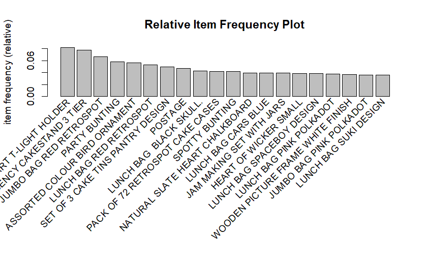

```r
# Create an item frequency plot for the top 20 items

itemFrequencyPlot(transaction,topN=20,type="relative", main="Relative Item Frequency Plot")
```

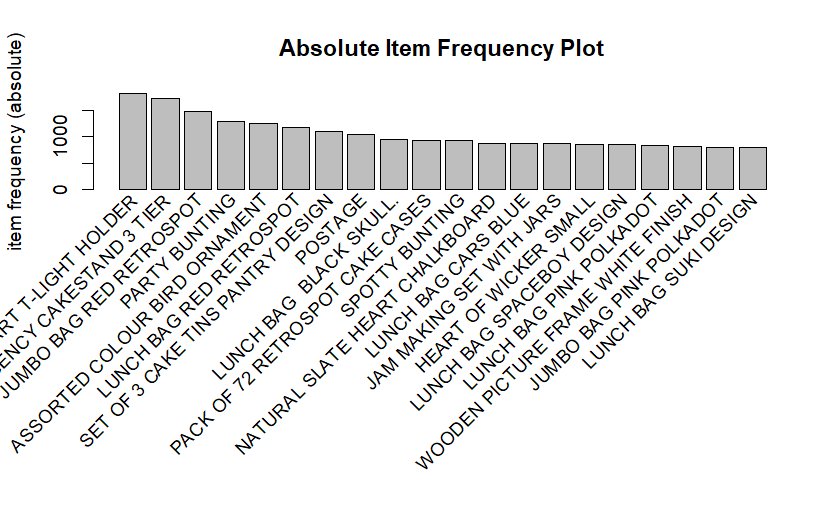

```r
itemFrequencyPlot(transaction,topN=20,type="absolute", horiz=FALSE, main="Absolute Item Frequency Plot")
```

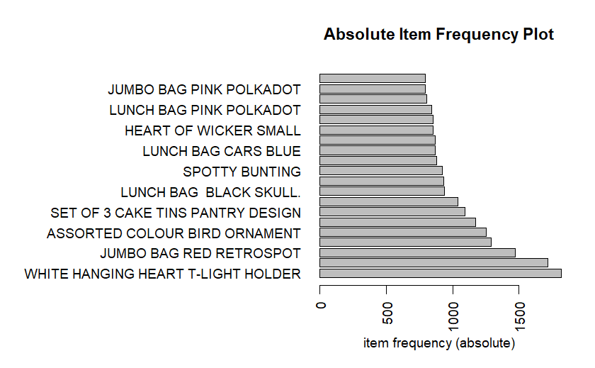

```r
itemFrequencyPlot(transaction,topN=20,type="absolute", horiz=TRUE, main="Absolute Item Frequency Plot")
```

Apriori Algorithm

As for summary below, we can see that 49676 rules are generated and a length of 5 items has the most rules. Below are some explanation of the rule itself.

Support 0.001 - The below rules applies at least 0.1% of carts must contain all items involved in the rule, which shows how prevelant this rule is in general

confidence of at least 80% (of the carts that contain the items in the LHS part of rule, at least 80% also have the item in the RHS of the rule, the rule is correct for at least 80% of carts)

minimum length of 2 (at least one item in the LHS and one item in the RHS) maximum length of 8 (max seven items in the LHS and one item in the RHS)

```r
# Apply Apriori in selecting rules
rules <- apriori(transaction, parameter = list(supp=0.001, conf = 0.8, minlen=2, maxlen=8)
                 , control = list(verbose=FALSE)
                 )
rules
```

```
set of 49676 rules
```

```r
summary(rules)
```

```
set of 49676 rules

rule length distribution (lhs + rhs):sizes
    2     3     4     5     6     7     8
  103  2162  6919 16792 15356  6344  2000

   Min. 1st Qu.  Median    Mean 3rd Qu.    Max.
    2.0     5.0     5.0     5.5     6.0     8.0

summary of quality measures:
    support         confidence      coverage           lift         count
 Min.   :0.0010   Min.   :0.80   Min.   :0.0010   Min.   : 10   Min.   : 23
 1st Qu.:0.0011   1st Qu.:0.83   1st Qu.:0.0013   1st Qu.: 22   1st Qu.: 24
 Median :0.0013   Median :0.88   Median :0.0014   Median : 28   Median : 28
 Mean   :0.0014   Mean   :0.88   Mean   :0.0016   Mean   : 63   Mean   : 31
 3rd Qu.:0.0015   3rd Qu.:0.93   3rd Qu.:0.0017   3rd Qu.: 67   3rd Qu.: 34
 Max.   :0.0161   Max.   :1.00   Max.   :0.0192   Max.   :716   Max.   :358

mining info:
```

|  | data | ntransactions | support | confidence | call |
| --- | --- | --- | --- | --- | --- |
|  | transaction | 22190 | 0.001 | 0.8 | apriori(data = transaction, parameter = list(supp = 0.001, conf = 0.8, minlen = 2, maxlen = 8), control = list(verbose = FALSE)) |

```r
# show the top 5 rules, but only 2 digits
options(digits=2) #changes the number of digits printed to the screen to 2
inspect(rules[1:5])
```

|  | lhs |  | rhs | support | confidence | coverage | lift | count |
| --- | --- | --- | --- | --- | --- | --- | --- | --- |
| [1] | {WOBBLY CHICKEN} | => | {DECORATION} | 0.0013 | 1.00 | 0.0013 | 444 | 28 |
| [2] | {WOBBLY CHICKEN} | => | {METAL} | 0.0013 | 1.00 | 0.0013 | 444 | 28 |
| [3] | {DECOUPAGE} | => | {GREETING CARD} | 0.0010 | 1.00 | 0.0010 | 389 | 23 |
| [4] | {BILLBOARD FONTS DESIGN} | => | {WRAP} | 0.0013 | 1.00 | 0.0013 | 716 | 29 |
| [5] | {WRAP} | => | {BILLBOARD FONTS DESIGN} | 0.0013 | 0.94 | 0.0014 | 716 | 29 |

Generating Rules using Apriori to mine frequent itemsets and association rules.

coverage = fraction of baskets that have all items in the LHS of rule count = #baskets that satisfy rule ( have all items referenced in rule) confidence : given the item on the LHS of rule, we are % confident that we see item on the RHS (posterior probability that cart has item on RHS given it has all items on LHS of rule ) Support = fraction of baskets that satisfy rule or fraction of baskets that have all items referenced in rule lift: how many times more likely that item in RHS appears in a cart when it contains all items in LHS #####################################################################

Further inspect rules and sorting by quality measure

```r
inspect(sort(rules, by="lift", decreasing = TRUE)[1:10])
```

```
     lhs                                  rhs                              support confidence coverage lift count
[1]  {BILLBOARD FONTS DESIGN}          => {WRAP}                            0.0013       1.00   0.0013  716    29
[2]  {WRAP}                            => {BILLBOARD FONTS DESIGN}          0.0013       0.94   0.0014  716    29
[3]  {ART LIGHTS}                      => {FUNK MONKEY}                     0.0018       1.00   0.0018  569    39
[4]  {FUNK MONKEY}                     => {ART LIGHTS}                      0.0018       1.00   0.0018  569    39
[5]  {CHOCOLATE  SPOTS}                => {SWISS ROLL TOWEL}                0.0019       1.00   0.0019  462    43
[6]  {SWISS ROLL TOWEL}                => {CHOCOLATE  SPOTS}                0.0019       0.90   0.0022  462    43
[7]  {CHILDS GARDEN RAKE PINK,
      CHILDS GARDEN SPADE BLUE,
      CHILDS GARDEN SPADE PINK}        => {CHILDS GARDEN RAKE BLUE}         0.0010       0.85   0.0012  461    23
[8]  {PARTY PIZZA DISH GREEN POLKADOT} => {PARTY PIZZA DISH PINK POLKADOT}  0.0010       0.82   0.0013  445    23
[9]  {WOBBLY CHICKEN}                  => {DECORATION}                      0.0013       1.00   0.0013  444    28
[10] {WOBBLY CHICKEN}                  => {METAL}                           0.0013       1.00   0.0013  444    28
```

```r
inspect(sort(rules, by="confidence", decreasing = TRUE)[1:10])
```

|  | lhs |  | rhs | support | confidence | coverage | lift | count |
| --- | --- | --- | --- | --- | --- | --- | --- | --- |
| [1] | {WOBBLY CHICKEN} | => | {DECORATION} | 0.0013 | 1 | 0.0013 | 444 | 28 |
| [2] | {WOBBLY CHICKEN} | => | {METAL} | 0.0013 | 1 | 0.0013 | 444 | 28 |
| [3] | {DECOUPAGE} | => | {GREETING CARD} | 0.0010 | 1 | 0.0010 | 389 | 23 |
| [4] | {BILLBOARD FONTS DESIGN} | => | {WRAP} | 0.0013 | 1 | 0.0013 | 716 | 29 |
| [5] | {WOBBLY RABBIT} | => | {DECORATION} | 0.0015 | 1 | 0.0015 | 444 | 34 |
| [6] | {WOBBLY RABBIT} | => | {METAL} | 0.0015 | 1 | 0.0015 | 444 | 34 |
| [7] | {BLACK TEA} | => | {SUGAR JARS} | 0.0021 | 1 | 0.0021 | 239 | 46 |
| [8] | {BLACK TEA} | => | {COFFEE} | 0.0021 | 1 | 0.0021 | 69 | 46 |
| [9] | {CHOCOLATE SPOTS} | => | {SWISS ROLL TOWEL} | 0.0019 | 1 | 0.0019 | 462 | 43 |
| [10] | {ART LIGHTS} | => | {FUNK MONKEY} | 0.0018 | 1 | 0.0018 | 569 | 39 |

```r
inspect(sort(rules, by="support", decreasing = TRUE)[1:10])
```

```
     lhs                                   rhs                               support confidence coverage lift count
[1]  {GREEN REGENCY TEACUP AND SAUCER,
      PINK REGENCY TEACUP AND SAUCER}   => {ROSES REGENCY TEACUP AND SAUCER}   0.016       0.84    0.019   24   358
[2]  {PINK REGENCY TEACUP AND SAUCER,
      ROSES REGENCY TEACUP AND SAUCER}  => {GREEN REGENCY TEACUP AND SAUCER}   0.016       0.88    0.018   29   358
[3]  {GREEN REGENCY TEACUP AND SAUCER,
      REGENCY CAKESTAND 3 TIER}         => {ROSES REGENCY TEACUP AND SAUCER}   0.013       0.82    0.016   24   281
[4]  {PINK REGENCY TEACUP AND SAUCER,
      REGENCY CAKESTAND 3 TIER}         => {GREEN REGENCY TEACUP AND SAUCER}   0.011       0.85    0.013   28   244
[5]  {PINK REGENCY TEACUP AND SAUCER,
      REGENCY CAKESTAND 3 TIER}         => {ROSES REGENCY TEACUP AND SAUCER}   0.011       0.85    0.013   25   242
[6]  {SET 3 RETROSPOT TEA}              => {SUGAR}                             0.010       1.00    0.010   96   231
[7]  {SUGAR}                            => {SET 3 RETROSPOT TEA}               0.010       1.00    0.010   96   231
[8]  {SET 3 RETROSPOT TEA}              => {COFFEE}                            0.010       1.00    0.010   69   231
[9]  {SUGAR}                            => {COFFEE}                            0.010       1.00    0.010   69   231
[10] {SET 3 RETROSPOT TEA,
      SUGAR}                            => {COFFEE}                            0.010       1.00    0.010   69   231
```

Here is some interpretation of the rules

We are seeing 28 carts contained wobbly chicken and decoration and 0.1% fractional of the cart that this rule applied (support). We’re 100% confident. Meaning if we going to look at all the transactions that has wobbly chicken, 100 % of them would have decoration.

We can also see that the itemFrequency (metric of support) shows the prior probability of finding the item and the confidence shows the posterior probability of finding the item given the existing items on the LHS of the rule.

```r
itemFrequency(transaction)["DECORATION"] # this is the prior probability of finding decoration in the cart 0.2% -- means support
```

```
DECORATION
    0.0023
```

```r
# so if the cart contains wobbly chicken, the probability of finding decoration is going to increase by a factor of 444 (444 times higher)

itemFrequency(transaction)["DECORATION"]  * 444  # the result of this turns out to be the confident of the rule 1
```

```
DECORATION
         1
```

```r
inspect(head(transaction, 4))
```

```
    items
[1] {536365,
     CREAM CUPID HEARTS COAT HANGER,
     GLASS STAR FROSTED T-LIGHT HOLDER,
     KNITTED UNION FLAG HOT WATER BOTTLE,
     RED WOOLLY HOTTIE WHITE HEART.,
     SET 7 BABUSHKA NESTING BOXES,
     WHITE HANGING HEART T-LIGHT HOLDER,
     WHITE METAL LANTERN}
[2] {536366,
     HAND WARMER RED POLKA DOT,
     HAND WARMER UNION JACK}
[3] {536367,
     ASSORTED COLOUR BIRD ORNAMENT,
     BOX OF 6 ASSORTED COLOUR TEASPOONS,
     BOX OF VINTAGE ALPHABET BLOCKS,
     BOX OF VINTAGE JIGSAW BLOCKS,
     DOORMAT NEW ENGLAND,
     FELTCRAFT PRINCESS CHARLOTTE DOLL,
     HOME BUILDING BLOCK WORD,
     IVORY KNITTED MUG COSY,
     LOVE BUILDING BLOCK WORD,
     POPPYS PLAYHOUSE BEDROOM,POPPYS PLAYHOUSE KITCHEN,
     RECIPE BOX WITH METAL HEART}
[4] {536368,
     BLUE COAT RACK PARIS FASHION,
     JAM MAKING SET WITH JARS,
     RED COAT RACK PARIS FASHION,
     YELLOW COAT RACK PARIS FASHION}
```

Questions that we can answer using APRIORI algorithms

1. What are customers likely to buy AFTER they purchase WHITE HANGING HEART T-LIGHT HOLDER, since this item has the highest frequency?

```r
rules<-apriori(transaction, parameter=list(supp=0.001,conf = 0.08, minlen=2),
               appearance = list(default="rhs",lhs="WHITE HANGING HEART T-LIGHT HOLDER"),
               control = list(verbose=FALSE))
rules<-sort(rules, decreasing=TRUE, by="confidence")
summary(rules)
```

```
set of 24 rules

rule length distribution (lhs + rhs):sizes
 2
24

   Min. 1st Qu.  Median    Mean 3rd Qu.    Max.
      2       2       2       2       2       2

summary of quality measures:
    support         confidence       coverage          lift         count
 Min.   :0.0066   Min.   :0.081   Min.   :0.082   Min.   :1.4   Min.   :147
 1st Qu.:0.0068   1st Qu.:0.083   1st Qu.:0.082   1st Qu.:2.1   1st Qu.:151
 Median :0.0082   Median :0.100   Median :0.082   Median :2.8   Median :181
 Mean   :0.0089   Mean   :0.109   Mean   :0.082   Mean   :3.3   Mean   :198
 3rd Qu.:0.0103   3rd Qu.:0.126   3rd Qu.:0.082   3rd Qu.:3.7   3rd Qu.:229
 Max.   :0.0174   Max.   :0.213   Max.   :0.082   Max.   :8.8   Max.   :386

mining info:
```

|  | data | ntransactions | support | confidence | call |
| --- | --- | --- | --- | --- | --- |
|  | transaction | 22190 | 0.001 | 0.08 | apriori(data = transaction, parameter = list(supp = 0.001, conf = 0.08, minlen = 2), appearance = list(default = "rhs", lhs = "WHITE HANGING HEART T-LIGHT HOLDER"), control = list(verbose = FALSE)) |

```r
inspect(rules[1:5])
```

```
    lhs                                     rhs                                 support confidence coverage lift count
[1] {WHITE HANGING HEART T-LIGHT HOLDER} => {RED HANGING HEART T-LIGHT HOLDER}    0.017       0.21    0.082  8.0   386
[2] {WHITE HANGING HEART T-LIGHT HOLDER} => {WOODEN PICTURE FRAME WHITE FINISH}   0.012       0.15    0.082  4.1   272
[3] {WHITE HANGING HEART T-LIGHT HOLDER} => {HEART OF WICKER LARGE}               0.011       0.14    0.082  4.2   249
[4] {WHITE HANGING HEART T-LIGHT HOLDER} => {PARTY BUNTING}                       0.011       0.14    0.082  2.4   249
[5] {WHITE HANGING HEART T-LIGHT HOLDER} => {ASSORTED COLOUR BIRD ORNAMENT}       0.011       0.13    0.082  2.3   236
```

2.What are customers likely to buy BEFORE they purchase WHITE HANGING HEART T-LIGHT HOLDER

```r
rules<-apriori(transaction, parameter=list(supp=0.001,conf = 0.08),
               appearance = list(default="lhs",rhs="WHITE HANGING HEART T-LIGHT HOLDER"),
               control = list(verbose=FALSE))
rules<-sort(rules, decreasing=TRUE,by="confidence")
inspect(rules[1:5])
```

```
    lhs                                   rhs                                  support confidence coverage lift count
[1] {CANDLEHOLDER PINK HANGING HEART,
     REX CASH+CARRY JUMBO SHOPPER}     => {WHITE HANGING HEART T-LIGHT HOLDER}  0.0013       0.90   0.0014   11    28
[2] {CANDLEHOLDER PINK HANGING HEART,
     ZINC METAL HEART DECORATION}      => {WHITE HANGING HEART T-LIGHT HOLDER}  0.0012       0.87   0.0014   11    27
[3] {CREAM HEART CARD HOLDER,
     RED HANGING HEART T-LIGHT HOLDER} => {WHITE HANGING HEART T-LIGHT HOLDER}  0.0014       0.86   0.0017   11    32
[4] {IVORY WICKER HEART LARGE,
     RED HANGING HEART T-LIGHT HOLDER} => {WHITE HANGING HEART T-LIGHT HOLDER}  0.0011       0.86   0.0013   10    24
[5] {CANDLEHOLDER PINK HANGING HEART,
     CLOTHES PEGS RETROSPOT PACK 24}   => {WHITE HANGING HEART T-LIGHT HOLDER}  0.0011       0.86   0.0013   10    24
```

Visualizing Rules

1. Interactive plot To see if there’s any hidden associations or relationships among the rules (i.e. clusters of the rules that we may not discover just by looking at the list)

```r
#####################################################################
# We probably don't want to visualize too many rules to cloud the image but enough to show the relationships among the rules, we are going to refit the algorithms here

simplerules <- apriori(transaction, parameter=list(supp=0.001,conf= 0.7,maxlen=3), control = list(verbose=F))

length((simplerules)) # we have ~5K rules in this scenario
```

```
[1] 5062
```

```r
#####################################################################
#select 10 rules from simple rules having the highest confidence.

top10simplerules <- head(simplerules, n = 10, by = "confidence")

#simplerules <- sort(simplerules, by = "lift")[c(1:13, 22:23, 98)] #selecting some for illustration
#plot(simplerules, method="graph", edgeCol="black", cex=0.7, alpha=1) # non-interactive
plot(top10simplerules, method="graph", engine="htmlwidget") # non-interactive
```

[interactive chart not shown]

```r
# Arrows pointing to rule are items in the LHS("if"), arrow leaving the rule point to item in the RHS ("then")

#####################################################################


saveAsGraph(head(simplerules, n = 1000, by = "lift"), file = "simplerules_1000.graphml")
```

```
To reduce overplotting, jitter is added! Use jitter = 0 to prevent jitter.
```

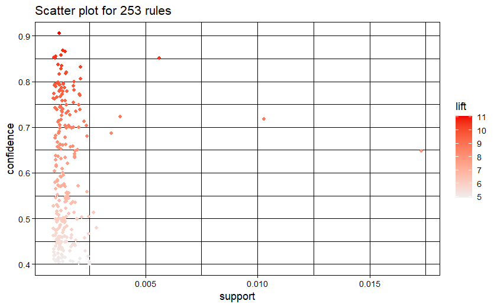

```r
# Filter rules with confidence greater than 0.4 or 40%

subRules<-rules[quality(rules)$confidence>0.4]
plot(subRules)
```

plot(rulesObject, measure, shading, method)

rulesObject: the rules object to be plotted

measure: Measures for rule interestingness. Can be Support, Confidence, lift or combination of these depending upon method value.

shading: Measure used to color points (Support, Confidence, lift). The default is Lift.

method: Visualization method to be used (scatterplot, two-key plot, matrix3D).

```
To reduce overplotting, jitter is added! Use jitter = 0 to prevent jitter.
```

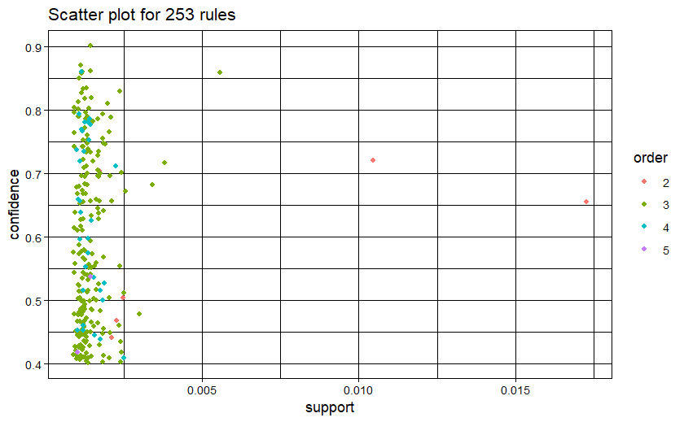

```r
plot(subRules,method="two-key plot")
```

The two-key plot uses support and confidence on x and y-axis respectively. It uses order for coloring. The order is the number of items in the rule.

Individual Rule Representation (Parallel Coordinates Plot)

To visualize which products along with which items cause what kind of sales.

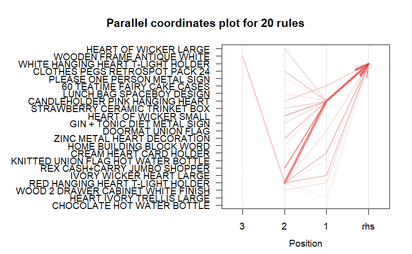

```r
# Filter top 20 rules with highest lift
subRules2<-head(subRules, n=20, by="lift")
plot(subRules2, method="paracoord")
```

As can see from the topmost arrow. It shows that when I have ‘WOODEN FRAME ANTIQUE WHITE’ , ‘RED HANGING HEART T_LIGHT HOLDER’ and CANDLEHOLDER PINK HANGING HEART in my shopping cart, I am likely to buy ‘WHITE HANDING HEART T-LIGHT HOLDER’ along with these as well.